# IODS course project

Now we standardize the dataset and see compare how the crime rate variable looks like when standardized.

```r
boston_s <- scale(Boston)

summary(boston_s)
```

```
##       crim                 zn               indus              chas
##  Min.   :-0.419367   Min.   :-0.48724   Min.   :-1.5563   Min.   :-0.2723
##  1st Qu.:-0.410563   1st Qu.:-0.48724   1st Qu.:-0.8668   1st Qu.:-0.2723
##  Median :-0.390280   Median :-0.48724   Median :-0.2109   Median :-0.2723
##  Mean   : 0.000000   Mean   : 0.00000   Mean   : 0.0000   Mean   : 0.0000
##  3rd Qu.: 0.007389   3rd Qu.: 0.04872   3rd Qu.: 1.0150   3rd Qu.:-0.2723
##  Max.   : 9.924110   Max.   : 3.80047   Max.   : 2.4202   Max.   : 3.6648
##       nox                rm               age               dis
##  Min.   :-1.4644   Min.   :-3.8764   Min.   :-2.3331   Min.   :-1.2658
##  1st Qu.:-0.9121   1st Qu.:-0.5681   1st Qu.:-0.8366   1st Qu.:-0.8049
##  Median :-0.1441   Median :-0.1084   Median : 0.3171   Median :-0.2790
##  Mean   : 0.0000   Mean   : 0.0000   Mean   : 0.0000   Mean   : 0.0000
##  3rd Qu.: 0.5981   3rd Qu.: 0.4823   3rd Qu.: 0.9059   3rd Qu.: 0.6617
##  Max.   : 2.7296   Max.   : 3.5515   Max.   : 1.1164   Max.   : 3.9566
##       rad               tax             ptratio            black
##  Min.   :-0.9819   Min.   :-1.3127   Min.   :-2.7047   Min.   :-3.9033
##  1st Qu.:-0.6373   1st Qu.:-0.7668   1st Qu.:-0.4876   1st Qu.: 0.2049
##  Median :-0.5225   Median :-0.4642   Median : 0.2746   Median : 0.3808
##  Mean   : 0.0000   Mean   : 0.0000   Mean   : 0.0000   Mean   : 0.0000
##  3rd Qu.: 1.6596   3rd Qu.: 1.5294   3rd Qu.: 0.8058   3rd Qu.: 0.4332
##  Max.   : 1.6596   Max.   : 1.7964   Max.   : 1.6372   Max.   : 0.4406
##      lstat              medv
##  Min.   :-1.5296   Min.   :-1.9063
##  1st Qu.:-0.7986   1st Qu.:-0.5989
##  Median :-0.1811   Median :-0.1449
##  Mean   : 0.0000   Mean   : 0.0000
##  3rd Qu.: 0.6024   3rd Qu.: 0.2683
##  Max.   : 3.5453   Max.   : 2.9865
```

```r
class(boston_s) # here boston_s is matrix/ array type data, we will make it into a dataset.
```

```
## [1] "matrix" "array"
```

```r
boston_s <-as.data.frame(boston_s) # now it is a data frame

# check how standardized crime values look like compared to previously:

summary(boston_s$crim)
```

```
##      Min.   1st Qu.    Median      Mean   3rd Qu.      Max.
## -0.419367 -0.410563 -0.390280  0.000000  0.007389  9.924110
```

```r
summary(Boston$crim)
```

```
##     Min.  1st Qu.   Median     Mean  3rd Qu.     Max.
##  0.00632  0.08204  0.25651  3.61352  3.67708 88.97620
```

```r
# Max was 88.9 and when standardized it is 9.92. Now all our variables are on a more directly comparable scale.

# Quantile variable creation:
bins <- quantile(boston_s$crim)
bins
```

```
##           0%          25%          50%          75%         100%
## -0.419366929 -0.410563278 -0.390280295  0.007389247  9.924109610
```

```r
# Turn that into a categorical variable 'crime'
boston_s$crime <- cut(boston_s$crim, breaks = bins, labels = c("low", "med_low", "med_high", "high"))

# look at the table of the new factor crime
summary(boston_s$crime)
```

```
##      low  med_low med_high     high     NA's
##      126      126      126      127        1
```

```r
# remove original crim from the scaled dataset
boston_s <- dplyr::select(boston_s, -crim)

# Now we have to divide the dataset to train and test sets so that 80% of the data belongs to the train set.

# number of rows in the Boston dataset
str(boston_s) # it is 506
```

```
## 'data.frame':    506 obs. of  14 variables:
##  $ zn     : num  0.285 -0.487 -0.487 -0.487 -0.487 ...
##  $ indus  : num  -1.287 -0.593 -0.593 -1.306 -1.306 ...
##  $ chas   : num  -0.272 -0.272 -0.272 -0.272 -0.272 ...
##  $ nox    : num  -0.144 -0.74 -0.74 -0.834 -0.834 ...
##  $ rm     : num  0.413 0.194 1.281 1.015 1.227 ...
##  $ age    : num  -0.12 0.367 -0.266 -0.809 -0.511 ...
##  $ dis    : num  0.14 0.557 0.557 1.077 1.077 ...
##  $ rad    : num  -0.982 -0.867 -0.867 -0.752 -0.752 ...
##  $ tax    : num  -0.666 -0.986 -0.986 -1.105 -1.105 ...
##  $ ptratio: num  -1.458 -0.303 -0.303 0.113 0.113 ...
##  $ black  : num  0.441 0.441 0.396 0.416 0.441 ...
##  $ lstat  : num  -1.074 -0.492 -1.208 -1.36 -1.025 ...
##  $ medv   : num  0.16 -0.101 1.323 1.182 1.486 ...
##  $ crime  : Factor w/ 4 levels "low","med_low",..: NA 1 1 1 1 1 2 2 2 2 ...
```

```r
n <- 506

# choose randomly 80% of the rows
ind <- sample(n,  size = n * 0.8, replace = FALSE)

# create train set
train <- boston_s[ind, ]

# create test set
test <- boston_s[-ind, ]

# save the correct classes from test data
correct_classes <- test$crime

# remove the crime variable from test data
test <- dplyr::select(test, -crime)
```

Now we fit the linear discriminant analysis on the train set using the categorical crime rate as the target variable and all the other variables in the dataset as predictor variables. Draw the LDA (bi)plot.

```r
# linear discriminant analysis
lda.fit <- lda(crime ~ ., data = train)

# print the lda.fit object
lda.fit
```

```
## Call:
## lda(crime ~ ., data = train)
##
## Prior probabilities of groups:
##       low   med_low  med_high      high
## 0.2555831 0.2332506 0.2630273 0.2481390
##
## Group means:
##                   zn      indus        chas        nox         rm        age
## low       1.01762242 -0.8899995 -0.08120770 -0.9021642  0.4343353 -0.8994535
## med_low  -0.09769684 -0.3485138 -0.02102480 -0.5986169 -0.1302824 -0.3845591
## med_high -0.37236182  0.1739988  0.21052285  0.3880412  0.1481490  0.4328941
## high     -0.48724019  1.0149946 -0.07547406  0.9801279 -0.3811242  0.7910835
##                 dis        rad        tax     ptratio      black       lstat
## low       0.8633893 -0.6819317 -0.7749396 -0.47455155  0.3754361 -0.75150709
## med_low   0.3545657 -0.5456981 -0.4733658 -0.08019541  0.3222631 -0.17541338
## med_high -0.3977913 -0.4022204 -0.3124074 -0.36859423  0.1033767  0.03230757
## high     -0.8436711  1.6596029  1.5294129  0.80577843 -0.9560278  0.87617741
##                  medv
## low       0.538393352
## med_low   0.002216477
## med_high  0.221996180
## high     -0.660730407
##
## Coefficients of linear discriminants:
##                 LD1         LD2        LD3
## zn       0.13876880  0.76771667 -1.0433014
## indus    0.05053482 -0.15863313 -0.1186467
## chas    -0.09186726 -0.06071827  0.0753281
## nox      0.20978415 -0.72121064 -1.1734718
## rm      -0.11629482 -0.14563625 -0.1678324
## age      0.28608567 -0.34207256 -0.1954540
## dis     -0.11826585 -0.32750345  0.1475207
## rad      3.39179117  1.19284649 -0.6654899
## tax      0.07895267 -0.42190716  1.3165248
## ptratio  0.12896126  0.09670369 -0.2581042
## black   -0.18017706 -0.02257262  0.0835793
## lstat    0.19049431 -0.29355217  0.2570572
## medv     0.19823322 -0.39660942 -0.1976907
##
## Proportion of trace:
##    LD1    LD2    LD3
## 0.9489 0.0389 0.0121
```

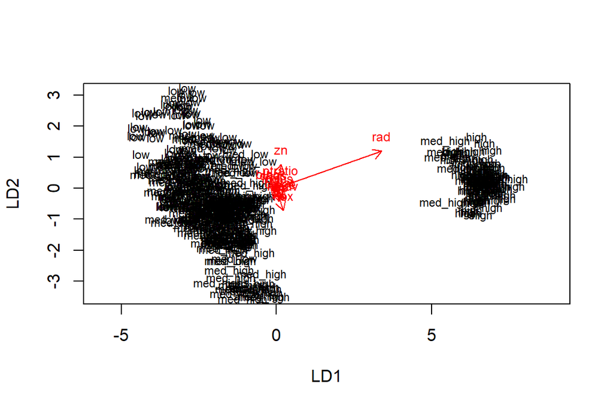

```r
# the function for lda biplot arrows
lda.arrows <- function(x, myscale = 1, arrow_heads = 0.1, color = "red", tex = 0.75, choices = c(1,2)){
  heads <- coef(x)
  graphics::arrows(x0 = 0, y0 = 0,
         x1 = myscale * heads[,choices[1]],
         y1 = myscale * heads[,choices[2]], col=color, length = arrow_heads)
  text(myscale * heads[,choices], labels = row.names(heads),
       cex = tex, col=color, pos=3)
}

# target classes as numeric
correct_classes <- as.numeric(train$crime)

# plot the lda results (select both lines and execute them at the same time!)
plot(lda.fit, dimen = 2)

lda.arrows(lda.fit, myscale = 1)
```

```r
library(GGally)
library(ggplot2)

data("Boston")
# Scale the whole original dataset Boston
bosnew <- scale(Boston)
summary(bosnew)
```

```
##       crim                 zn               indus              chas
##  Min.   :-0.419367   Min.   :-0.48724   Min.   :-1.5563   Min.   :-0.2723
##  1st Qu.:-0.410563   1st Qu.:-0.48724   1st Qu.:-0.8668   1st Qu.:-0.2723
##  Median :-0.390280   Median :-0.48724   Median :-0.2109   Median :-0.2723
##  Mean   : 0.000000   Mean   : 0.00000   Mean   : 0.0000   Mean   : 0.0000
##  3rd Qu.: 0.007389   3rd Qu.: 0.04872   3rd Qu.: 1.0150   3rd Qu.:-0.2723
##  Max.   : 9.924110   Max.   : 3.80047   Max.   : 2.4202   Max.   : 3.6648
##       nox                rm               age               dis
##  Min.   :-1.4644   Min.   :-3.8764   Min.   :-2.3331   Min.   :-1.2658
##  1st Qu.:-0.9121   1st Qu.:-0.5681   1st Qu.:-0.8366   1st Qu.:-0.8049
##  Median :-0.1441   Median :-0.1084   Median : 0.3171   Median :-0.2790
##  Mean   : 0.0000   Mean   : 0.0000   Mean   : 0.0000   Mean   : 0.0000
##  3rd Qu.: 0.5981   3rd Qu.: 0.4823   3rd Qu.: 0.9059   3rd Qu.: 0.6617
##  Max.   : 2.7296   Max.   : 3.5515   Max.   : 1.1164   Max.   : 3.9566
##       rad               tax             ptratio            black
##  Min.   :-0.9819   Min.   :-1.3127   Min.   :-2.7047   Min.   :-3.9033
##  1st Qu.:-0.6373   1st Qu.:-0.7668   1st Qu.:-0.4876   1st Qu.: 0.2049
##  Median :-0.5225   Median :-0.4642   Median : 0.2746   Median : 0.3808
##  Mean   : 0.0000   Mean   : 0.0000   Mean   : 0.0000   Mean   : 0.0000
##  3rd Qu.: 1.6596   3rd Qu.: 1.5294   3rd Qu.: 0.8058   3rd Qu.: 0.4332
##  Max.   : 1.6596   Max.   : 1.7964   Max.   : 1.6372   Max.   : 0.4406
##      lstat              medv
##  Min.   :-1.5296   Min.   :-1.9063
##  1st Qu.:-0.7986   1st Qu.:-0.5989
##  Median :-0.1811   Median :-0.1449
##  Mean   : 0.0000   Mean   : 0.0000
##  3rd Qu.: 0.6024   3rd Qu.: 0.2683
##  Max.   : 3.5453   Max.   : 2.9865
```

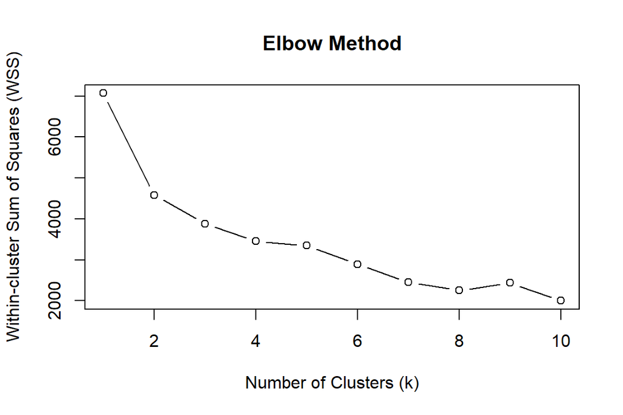

```r
# Calculate distances between observations (using Euclidean distance)
distances <- dist(bosnew)

# Run k-means algorithm on the dataset
# For initial exploration, choose an arbitrary number of clusters, e.g., k = 4
k <- 4
kmeans_result <- kmeans(bosnew, centers = k)

# Elbow method to determine the optimal number of clusters
wss <- numeric(10)  # Within-cluster sum of squares
for (i in 1:10) {
  kmeans_temp <- kmeans(bosnew, centers = i)
  wss[i] <- kmeans_temp$tot.withinss
}

# Plot the Elbow curve
plot(1:10, wss, type = "b", xlab = "Number of Clusters (k)", ylab = "Within-cluster Sum of Squares (WSS)", main = "Elbow Method")
```

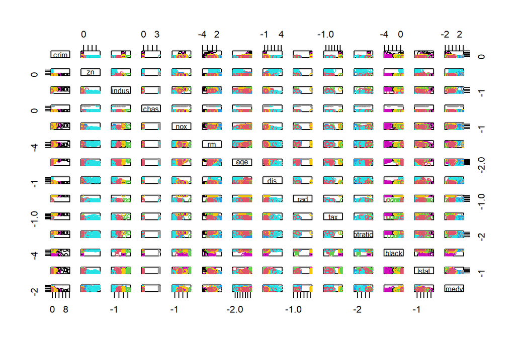

```r
# 8 seems to be the optimal number of clusters. Re-run k-means with the optimal number of clusters
optimal_k <- 8 #Choose the optimal number of clusters based on the Elbow plot
kmeans_optimal <- kmeans(bosnew, centers = optimal_k)

pairs(bosnew, col = kmeans_optimal$cluster)
```

# *Chapter 5*

We are working on the Human Development Index data which explores different aspects of human life qualities in different countries. Along with the data also discriminates between genders in order to explore disadvantages/advantages.

We download the data and read it into human.

```
## # A tibble: 155 × 9
##    Country      Edu2.FM Labo.FM Life.Exp Edu.Exp   GNI Mat.Mor Ado.Birth Parli.F
##    <chr>          <dbl>   <dbl>    <dbl>   <dbl> <dbl>   <dbl>     <dbl>   <dbl>
##  1 Norway         1.01    0.891     81.6    17.5 64992       4       7.8    39.6
##  2 Australia      0.997   0.819     82.4    20.2 42261       6      12.1    30.5
##  3 Switzerland    0.983   0.825     83      15.8 56431       6       1.9    28.5
##  4 Denmark        0.989   0.884     80.2    18.7 44025       5       5.1    38
##  5 Netherlands    0.969   0.829     81.6    17.9 45435       6       6.2    36.9
##  6 Germany        0.993   0.807     80.9    16.5 43919       7       3.8    36.9
##  7 Ireland        1.02    0.780     80.9    18.6 39568       9       8.2    19.9
##  8 United Stat…   1.00    0.817     79.1    16.5 52947      28      31      19.4
##  9 Canada         1       0.868     82      15.9 42155      11      14.5    28.2
## 10 New Zealand    0.997   0.840     81.8    19.2 32689       8      25.3    31.4
## # ℹ 145 more rows
```

We need to move the country names to row names show a graphical overview and summaries of this data and interpret it.

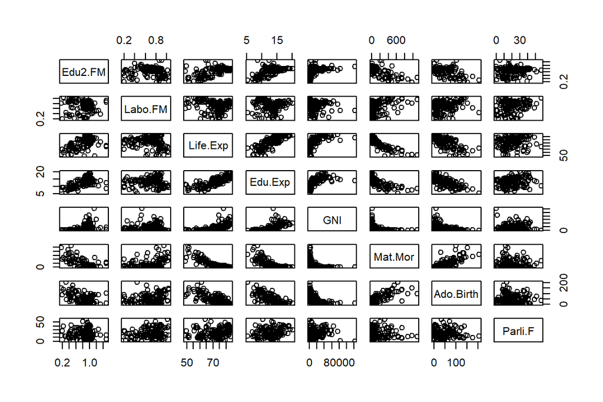

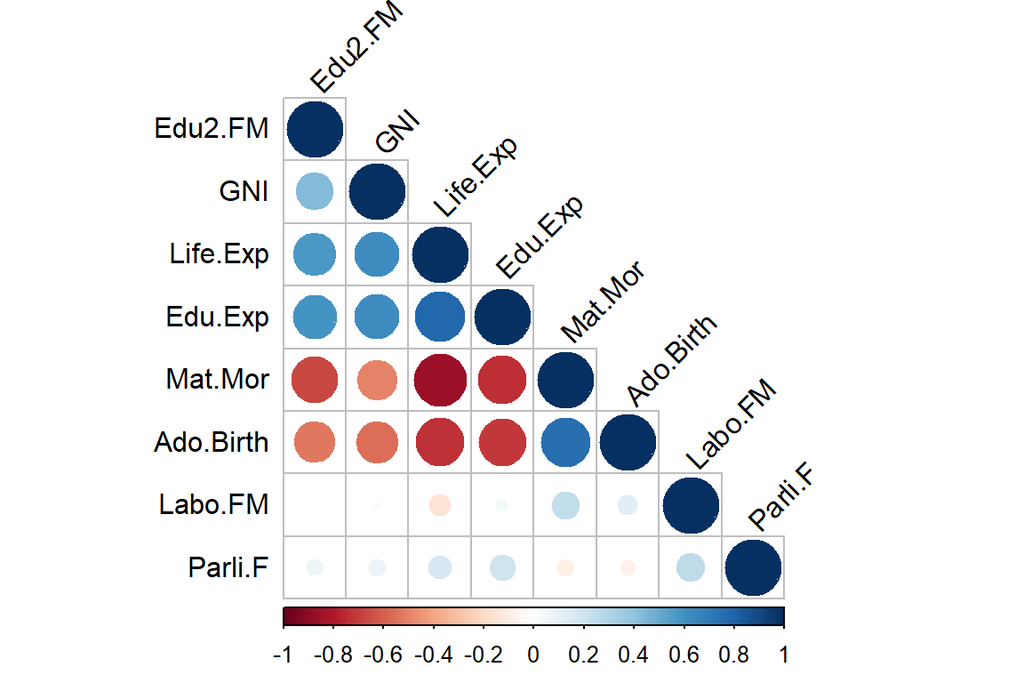

We will need the full names of the variables: “Country” = Country name

Health and knowledge:

“GNI” = Gross National Income per capita “Life.Exp” = Life expectancy at birth “Edu.Exp” = Expected years of schooling “Mat.Mor” = Maternal mortality ratio “Ado.Birth” = Adolescent birth rate

Empowerment:

“Parli.F” = Percetange of female representatives in parliament “Edu2.F” = Proportion of females with at least secondary education “Edu2.M” = Proportion of males with at least secondary education “Labo.F” = Proportion of females in the labour force “Labo.M” ” Proportion of males in the labour force

Overall the correlations seem quite logical. As the higher education and life expectancy relate to higher Gross national income. And these correlate with lower maternal mortalities and adolescent births. Interestingly there is not much connection between female representatives in parliment or female to male ratio in work forces, these seem to be independent of the other factors.

PCA analysis on the non standardized data.

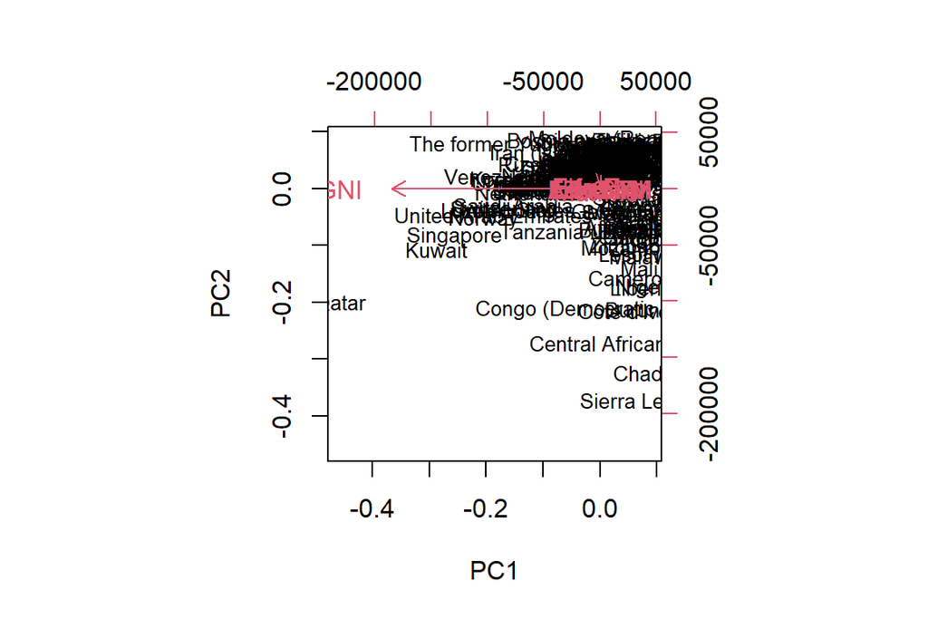

PCA analysis of the standardized data:

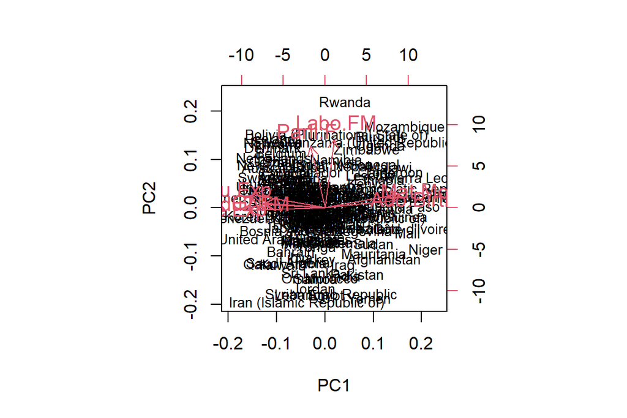

Tea Questionnaire:

```
##         Tea         How           sugar                      where
##  black    : 74   alone:195   No.sugar:155   chain store         :192
##  Earl Grey:193   lemon: 33   sugar   :145   chain store+tea shop: 78
##  green    : 33   milk : 63                  tea shop            : 30
##                  other:  9
##        lunch
##  lunch    : 44
##  Not.lunch:256
##
##
```

```
## 'data.frame':    300 obs. of  5 variables:
##  $ Tea  : Factor w/ 3 levels "black","Earl Grey",..: 1 1 2 2 2 2 2 1 2 1 ...
##  $ How  : Factor w/ 4 levels "alone","lemon",..: 1 3 1 1 1 1 1 3 3 1 ...
##  $ sugar: Factor w/ 2 levels "No.sugar","sugar": 2 1 1 2 1 1 1 1 1 1 ...
##  $ where: Factor w/ 3 levels "chain store",..: 1 1 1 1 1 1 1 1 2 2 ...
##  $ lunch: Factor w/ 2 levels "lunch","Not.lunch": 2 2 2 2 2 2 2 2 2 2 ...
```

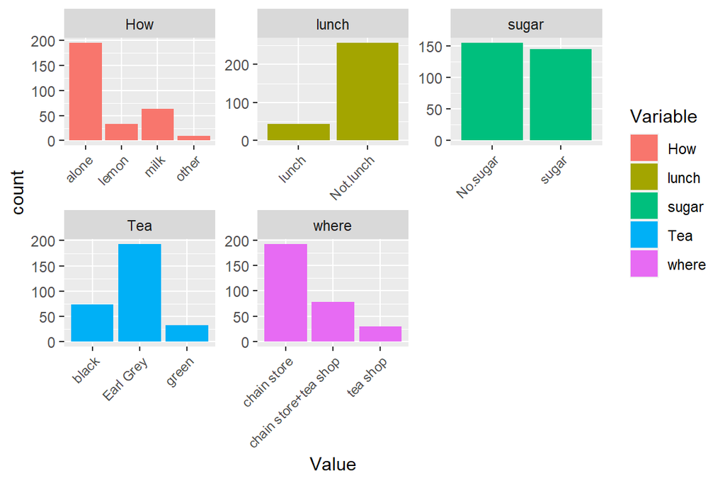

It seems like most people drink their earl grey alone very rarely at lunch. People who prefer their tea with sugar are as many as the ones who prefer it without. Most of the people get their tea from a chain store.

```
##
## Call:
## MCA(X = tea_time, graph = FALSE)
##
##
## Eigenvalues
##                        Dim.1   Dim.2   Dim.3   Dim.4   Dim.5   Dim.6   Dim.7
## Variance               0.268   0.266   0.239   0.214   0.196   0.177   0.167
## % of var.             14.896  14.799  13.295  11.914  10.866   9.807   9.268
## Cumulative % of var.  14.896  29.695  42.990  54.904  65.770  75.578  84.846
##                        Dim.8   Dim.9
## Variance               0.148   0.124
## % of var.              8.244   6.910
## Cumulative % of var.  93.090 100.000
##
## Individuals (the 10 first)
##                Dim.1    ctr   cos2    Dim.2    ctr   cos2    Dim.3    ctr
## 1           | -0.174  0.038  0.028 |  0.214  0.058  0.043 | -0.312  0.136
## 2           |  0.008  0.000  0.000 |  0.670  0.562  0.265 | -0.357  0.177
## 3           | -0.338  0.142  0.206 |  0.024  0.001  0.001 | -0.300  0.125
## 4           | -0.161  0.032  0.045 | -0.452  0.256  0.353 | -0.347  0.168
## 5           | -0.338  0.142  0.206 |  0.024  0.001  0.001 | -0.300  0.125
## 6           | -0.338  0.142  0.206 |  0.024  0.001  0.001 | -0.300  0.125
## 7           | -0.338  0.142  0.206 |  0.024  0.001  0.001 | -0.300  0.125
## 8           |  0.008  0.000  0.000 |  0.670  0.562  0.265 | -0.357  0.177
## 9           |  0.589  0.431  0.209 |  0.183  0.042  0.020 | -0.095  0.012
## 10          |  0.218  0.059  0.031 |  0.869  0.946  0.501 |  0.033  0.002
##               cos2
## 1            0.090 |
## 2            0.075 |
## 3            0.163 |
## 4            0.208 |
## 5            0.163 |
## 6            0.163 |
## 7            0.163 |
## 8            0.075 |
## 9            0.005 |
## 10           0.001 |
##
## Categories (the 10 first)
```

[output cut: 15 more lines]

```
## alone       |  -0.162   1.433   0.049  -3.828 |
## lemon       |   1.811  30.139   0.405  11.007 |
## milk        |  -0.388   2.639   0.040  -3.457 |
## other       |  -0.405   0.412   0.005  -1.233 |
## No.sugar    |   0.056   0.136   0.003   1.002 |
## sugar       |  -0.060   0.145   0.003  -1.002 |
## chain store |  -0.461  11.364   0.378 -10.627 |
##
## Categorical variables (eta2)
##               Dim.1 Dim.2 Dim.3
## Tea         | 0.326 0.528 0.112 |
## How         | 0.442 0.304 0.414 |
## sugar       | 0.052 0.377 0.003 |
## where       | 0.474 0.041 0.663 |
## lunch       | 0.046 0.081 0.004 |
```

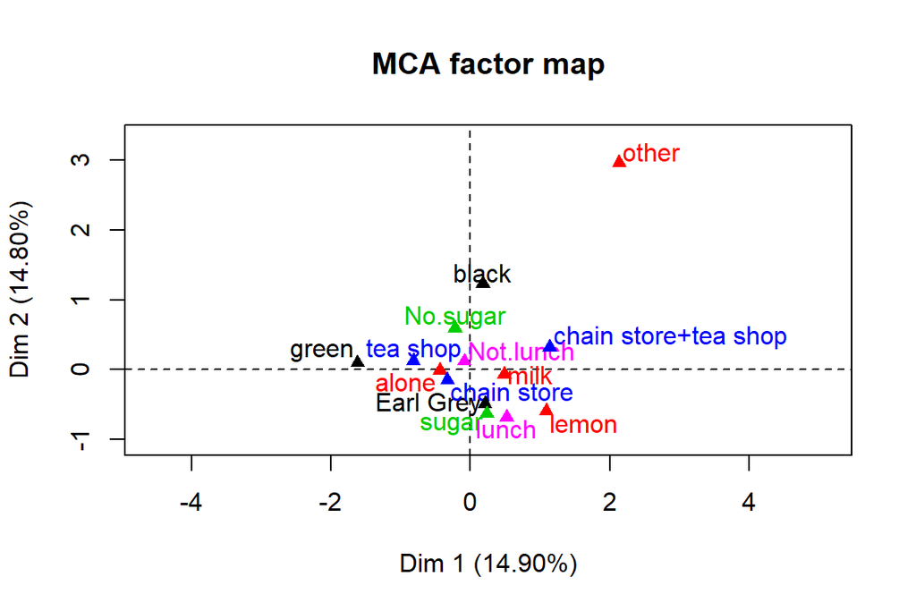